# Conceitos no Livro de Notas do moodle

## Como mostrar conceitos no moodle?

- Usando `Escalas`? O problema é como configurar uma nova `Escala`… documentação não parece clara.
- Nós fizemos uma cópia da coluna ‘total do curso’ (ou copiar a coluna que contém a média final)
  - e então selecionamos a opção para mostrar `Letras`
  - (é necessário definir `Letras` de acordo com os conceitos)

Iniciamos em configuraçãoo do livro de notas

[figure not shown]

No fim da página selecionamos adicionar novo item de nota.

[figure not shown]

O item deve ser de `Valor`, porém se clicarmos em ‘mostrar mais…’

[figure not shown]

podemos selecionar para o item ser apresentado como `Letra`.

[figure not shown]

Agora, para copiar os valores da média final voltamos às configurações do livro de notas, procuramos a linha referente ao conceito criado e clicar em editar cálculo.

[figure not shown]

Usando caixa de fórmulas definimos os valores que queremos copiar.

[figure not shown]

Por fim, temos uma cópia da coluna média final que apresenta `Letras` ao invés de valores.

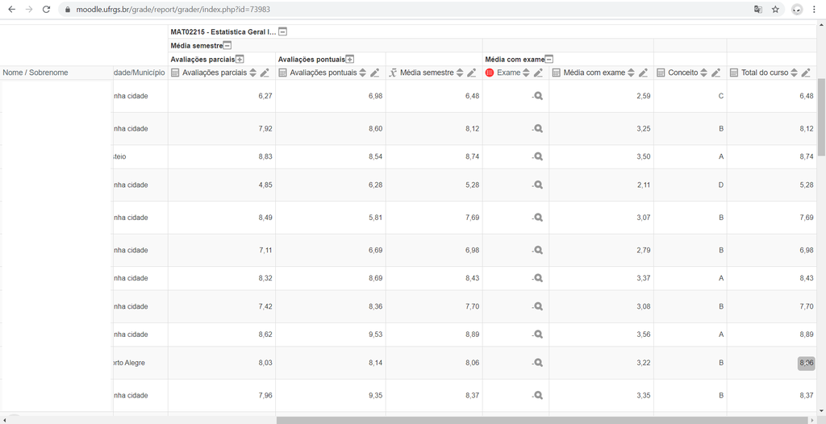

*Obs.: Se utilizar arredondamentos para atingir próximo conceito fazer manualmente, ou modificar os limites para `Letras`.*

### Referências

- `Letras` - https://docs.moodle.org/310/en/Grade_letters
- mais um pouco de `Letras` - https://www.umass.edu/it/support/moodle/letter-grades-moodle
- Editar cálculos - https://docs.moodle.org/310/en/Grade_calculations
- ??? `Escalas` - https://docs.moodle.org/310/en/Scales#Editing_a_scale